# Comparative analysis in Seurat v5

Compiled: 2026-09-10

load libraries

```r
library(Seurat)
library(BPCells)
library(tidyverse)
library(harmony)
library(viridisLite)
# needs to be set for large dataset analysis
options(future.globals.maxSize = 1e9)
```

#how to access the data Due to limited time we will not go through the process of downloading the data and creating Seurat object. A lot of publications deposit their data on GEO database where you can often find 3 files stored as supplement: matrix (mtx): counts, gene expression barcodes (tsv): sells features (tsv): genes Look for data availability in the end of the publication.

code example on whre to download the data and how to create Seurat object from it is pastedbelow. We do not need this code for the excercise. It it is pasted here just as modifiable example if you would like to use another data set. This example will work with mapped datasets. If the data is published as raw data (before genome mapping) then you would need to do this step as well.

```r
#https://www.ncbi.nlm.nih.gov/geo/query/acc.cgi?acc=GSM5067109
#expression_matrix <- ReadMtx(mtx = "C:/Users/Kaja Moczulska/Downloads/GSM5067109_EKO_matrix.mtx.gz",
#                             cells = "C:/Users/Kaja Moczulska/Downloads/GSM5067109_EKO_barcodes.tsv.gz",
#                             features = "C:/Users/Kaja Moczulska/Downloads/GSM5067109_EKO_genes.tsv.gz")
#Seurat_AD <- CreateSeuratObject(expression_matrix)
#saveRDS(
#  object = Seurat_AD,
#  file = "Eko_hippo.rds")
#
#rm(expression_matrix)
```

# Standard pre-processing workflow

The steps below encompass the standard pre-processing workflow for scRNA-seq data in Seurat. These represent the selection and filtration of cells based on QC metrics, data normalization and scaling, and the detection of highly variable features.

## QC and selecting cells for further analysis

Seurat allows you to easily explore QC metrics and filter cells based on any user-defined criteria. A few QC metrics [commonly used](https://www.ncbi.nlm.nih.gov/pmc/articles/PMC4758103/) by the community include

nFeatures: number of unique genes detected in a cell nCount: total number of RNA molecules detected in that same cell

```r
#load datasets
setwd("~/data")
Seurat_AD <- LoadSeuratRds('./Input_data/Eko_hippo.rds')
Seurat_WT <- LoadSeuratRds('./Input_data/WT_hippo.rds')
condition <- vector(mode="character", length=length(Seurat_AD$orig.ident))
condition [1:length(condition)] <- "AD"
Seurat_AD <- AddMetaData(object = Seurat_AD, metadata = condition, col.name = "condition")

condition <- vector(mode="character", length=length(Seurat_WT$orig.ident))
condition [1:length(condition)] <- "WT"
Seurat_WT <- AddMetaData(object = Seurat_WT, metadata = condition, col.name = "condition")

rm(condition)
```

```r
# The [[ operator can add columns to object metadata. This is a great place to stash QC stats
Seurat_AD[["percent.mt"]] <- PercentageFeatureSet(Seurat_AD, pattern = "^mt-")
Seurat_WT[["percent.mt"]] <- PercentageFeatureSet(Seurat_WT, pattern = "^mt-")
```

## Filter out the bad quality cells

```r
Seurat_AD <- subset(Seurat_AD, subset = nFeature_RNA < 2500 & percent.mt < 5)
Seurat_WT <- subset(Seurat_WT, subset = nFeature_RNA < 2500  & percent.mt < 5)
```

## Normalize and find variable genes for each data set

```r
Seurat_WT <- NormalizeData(Seurat_WT)
Seurat_AD <- NormalizeData(Seurat_AD)
Seurat_WT <- FindVariableFeatures(Seurat_WT)
Seurat_AD <- FindVariableFeatures(Seurat_AD)
```

Now our data is cleaned and normalised and ready to compare with the second dataset (in our case with data from WT mice). However, we need to preprocess the other dataset as well.

# Merging data sets

In order to integrate the data sets we will form a merged object first. merge() funciton will by default erase normalisation data. Here we used the same normalisation for both data sets, so we can keep it in merged object (use parameter merge.data = TRUE).

```r
Seurat_AD_WT <- merge(Seurat_AD, y = Seurat_WT,
                              add.cell.ids = c("AD", "WT"),
                              merge.data = TRUE)
```

And normalise merged dataset:

```r
Seurat_AD_WT <- NormalizeData(Seurat_AD_WT)
```

Now let’s have a look at object info for all 3 objects:

```r
Seurat_WT
```

```
## An object of class Seurat
## 27998 features across 5363 samples within 1 assay
## Active assay: RNA (27998 features, 2000 variable features)
##  2 layers present: counts, data
```

```r
Seurat_AD
```

```
## An object of class Seurat
## 27998 features across 5446 samples within 1 assay
## Active assay: RNA (27998 features, 2000 variable features)
##  2 layers present: counts, data
```

```r
Seurat_AD_WT
```

```
## An object of class Seurat
## 27998 features across 10809 samples within 1 assay
## Active assay: RNA (27998 features, 2000 variable features)
##  4 layers present: counts.1, counts.2, data.1, data.2
```

# Intro: Integrative analysis in Seurat v5

Integration of single-cell sequencing datasets, for example across experimental batches, donors, or conditions, is often an important step in scRNA-seq workflows. Integrative analysis can help to match shared cell types and states across datasets, which can boost statistical power, and most importantly, facilitate accurate comparative analysis across datasets. In previous versions of Seurat we introduced methods for integrative analysis, including our ‘anchor-based’ integration workflow. Many labs have also published powerful and pioneering methods, including Harmony and scVI, for integrative analysis. We recognize that while the goal of matching shared cell types across datasets may be important for many problems, users may also be concerned about which method to use, or that integration could result in a loss of biological resolution. In Seurat v5, we introduce more flexible and streamlined infrastructure to run different integration algorithms with a single line of code. This makes it easier to explore the results of different integration methods, and to compare these results to a workflow that excludes integration steps. based on vignette https://satijalab.org/seurat/articles/seurat5_integration#layers-in-the-seurat-v5-object

We will first proceed WITHOUT data integration for comparative reasons:

## Identification of highly variable features (feature selection)

We calculate a subset of features that exhibit high cell-to-cell variation in the dataset (i.e, they are highly expressed in some cells, and lowly expressed in others). We and [others](https://www.nature.com/articles/nmeth.2645) have found that focusing on these genes in downstream analysis helps to highlight biological signal in single-cell datasets.

Our procedure in Seurat is described in detail [here](https://doi.org/10.1016/j.cell.2019.05.031), and improves on previous versions by directly modeling the mean-variance relationship inherent in single-cell data, and is implemented in the `FindVariableFeatures()` function. By default, we return 2,000 features per dataset. These will be used in downstream analysis, like PCA.

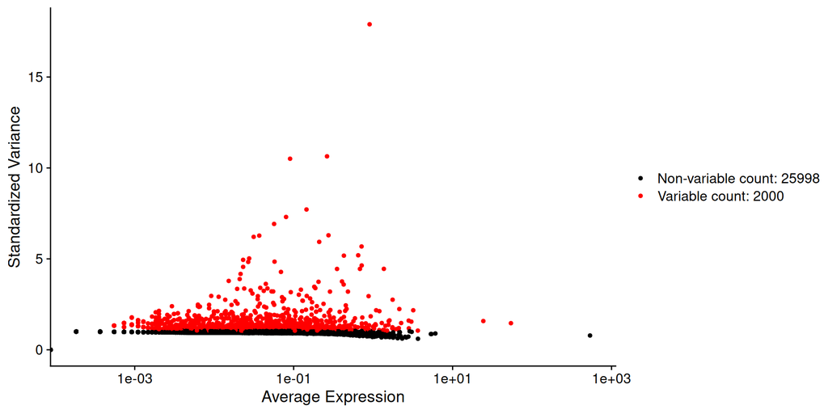

```r
Seurat_AD_WT <- FindVariableFeatures(Seurat_AD_WT)

# plot variable features with and without labels
 VariableFeaturePlot(Seurat_AD_WT)
```

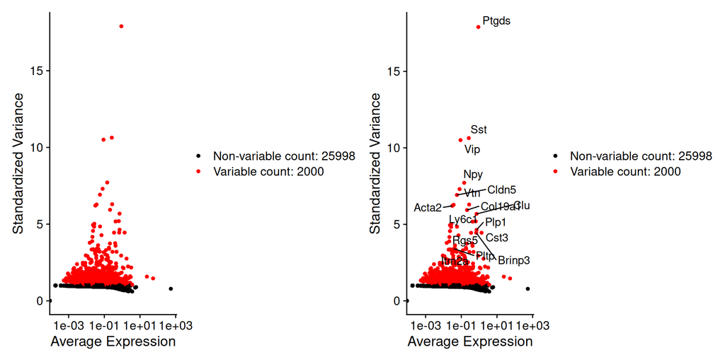

```r
# Identify the 20 most highly variable genes
top20 <- head(VariableFeatures(Seurat_AD_WT), 20)

# plot variable features with and without labels
plot1 <- VariableFeaturePlot(Seurat_AD_WT)
plot2 <- LabelPoints(plot = plot1, points = top20, repel = TRUE)
plot1 + plot2
```

Lets compare the Variable genes between the merged and single data sets

```r
# Identify the 20 most highly variable genes
top20 <- head(VariableFeatures(Seurat_AD_WT), 20)
top20_WT <- head(VariableFeatures(Seurat_WT), 20)
top20_AD <- head(VariableFeatures(Seurat_AD), 20)
print(paste0("Merged data: ", paste(sort(top20),collapse=",")))
```

```
## [1] "Merged data: Acta2,Brinp3,Cldn5,Clu,Col19a1,Cst3,Igfbp7,Itm2a,Ly6a,Ly6c1,Myoc,Npy,Plp1,Pltp,Ptgds,Rgs5,Slco1a4,Sst,Vip,Vtn"
```

```r
print(paste0("WT data: ", paste(sort(top20_WT),collapse=",")))
```

```
## [1] "WT data: Apoe,Brinp3,Bsg,Cldn5,Col19a1,Flt1,Hspb1,Igfbp7,Itm2a,Klf2,Ly6c1,Npy,Pltp,Ptgds,Rgs5,Slco1a4,Sst,Ttr,Vip,Vtn"
```

```r
print(paste0("AD data: ", paste(sort(top20_AD),collapse=",")))
```

```
## [1] "AD data: Acta2,Cldn5,Clu,Col19a1,Cst3,Gh,Igfbp7,Ly6a,Ly6c1,Myl9,Myoc,Npy,Plp1,Prl,Ptgds,Slc1a2,Slco1a4,Sst,Vip,Vtn"
```

```r
vec_list <- list(Merge = VariableFeatures(Seurat_AD_WT),
                 WT =  VariableFeatures(Seurat_WT),
                 AD = VariableFeatures(Seurat_AD))
# Create an overlap matrix
overlap_matrix <- outer(vec_list, vec_list, Vectorize(function(x, y) length(intersect(x, y))))

print("Raw numbers")
```

```
## [1] "Raw numbers"
```

```r
print(overlap_matrix)
```

```
##       Merge   WT   AD
## Merge  2000 1619 1575
## WT     1619 2000 1194
## AD     1575 1194 2000
```

```r
print("Percent overlap")
```

```
## [1] "Percent overlap"
```

```r
print(overlap_matrix/2000*100)
```

```
##        Merge     WT     AD
## Merge 100.00  80.95  78.75
## WT     80.95 100.00  59.70
## AD     78.75  59.70 100.00
```

## Scaling the data

Next, we apply a linear transformation (‘scaling’) that is a standard pre-processing step prior to dimensional reduction techniques like PCA. The `ScaleData()` function:

```r
Seurat_AD_WT <- ScaleData(Seurat_AD_WT)
```

## Perform linear dimensional reduction

Next we perform PCA on the scaled data. By default, only the previously determined variable features are used as input, but can be defined using `features` argument if you wish to choose a different subset (if you do want to use a custom subset of features, make sure you pass these to `ScaleData` first).

For the first principal components, Seurat outputs a list of genes with the most positive and negative loadings, representing modules of genes that exhibit either correlation (or anti-correlation) across single-cells in the dataset.

```r
Seurat_AD_WT <- RunPCA(Seurat_AD_WT, features = VariableFeatures(object = Seurat_AD_WT), npcs = 25)
```

Seurat provides several useful ways of visualizing both cells and features that define the PCA, including `VizDimReduction()`, `DimPlot()`, and `DimHeatmap()`

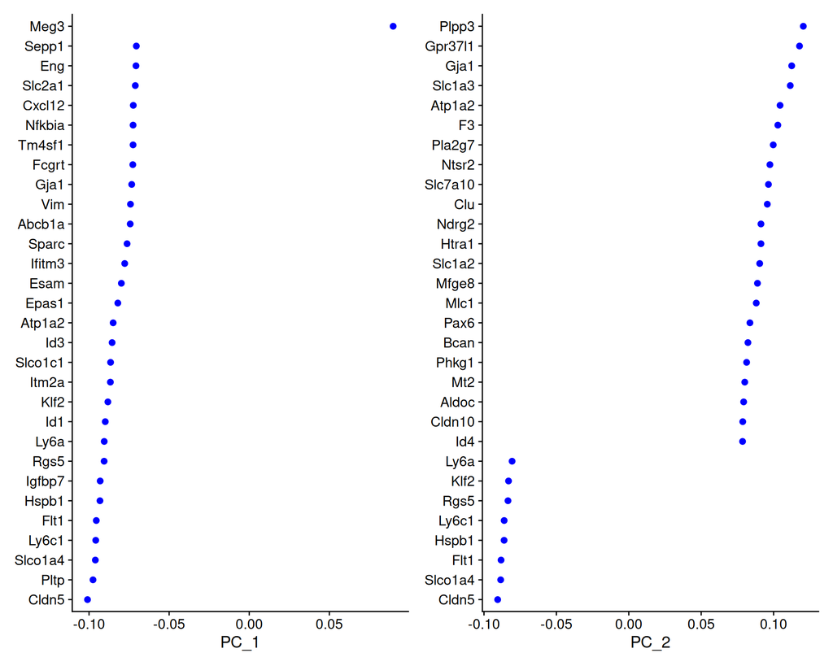

```r
# Examine and visualize PCA results a few different ways
VizDimLoadings(Seurat_AD_WT, dims = 1:2, reduction = 'pca')
```

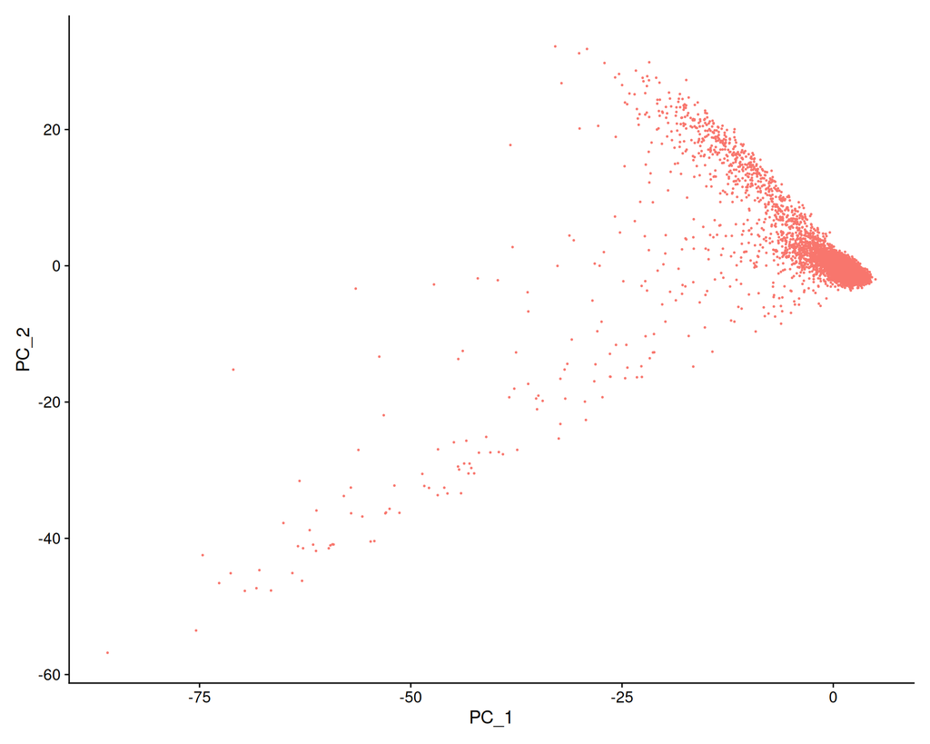

```r
DimPlot(Seurat_AD_WT, reduction = 'pca') + NoLegend()
```

In particular `DimHeatmap()` allows for easy exploration of the primary sources of heterogeneity in a dataset, and can be useful when trying to decide which PCs to include for further downstream analyses. Both cells and features are ordered according to their PCA scores. Setting `cells` to a number plots the ‘extreme’ cells on both ends of the spectrum, which dramatically speeds plotting for large datasets. Though clearly a supervised analysis, we find this to be a valuable tool for exploring correlated feature sets.

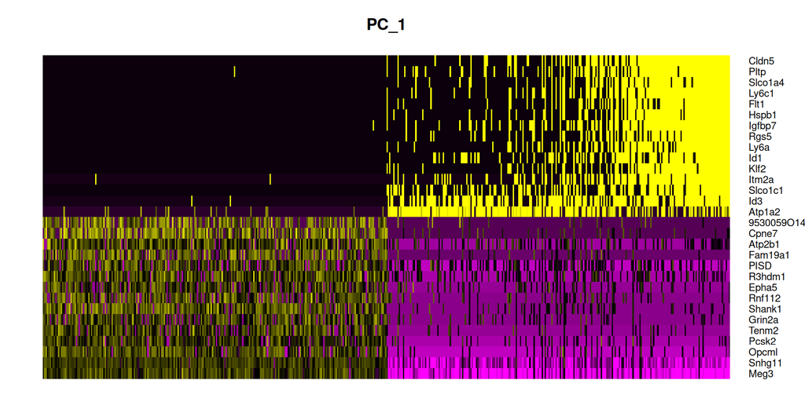

```r
DimHeatmap(Seurat_AD_WT, dims = 1, cells = 500, balanced = TRUE)
```

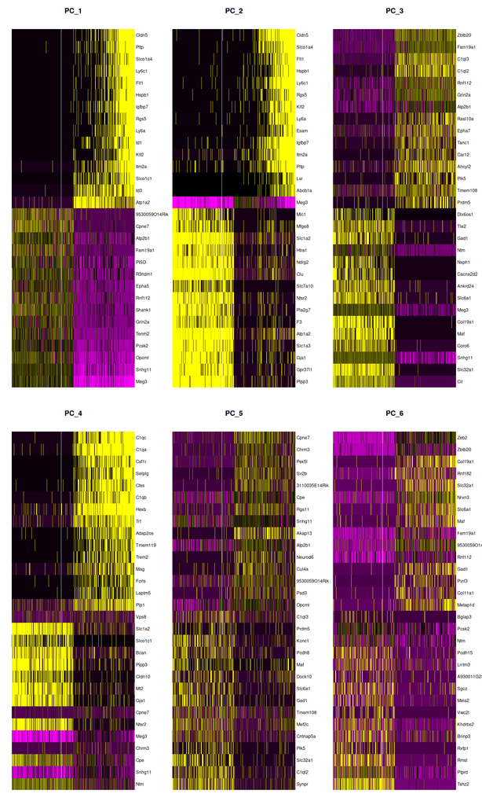

```r
DimHeatmap(Seurat_AD_WT, dims = 1:6, cells = 500, balanced = TRUE)
```

## Determine the ‘dimensionality’ of the dataset

To overcome the extensive technical noise in any single feature for scRNA-seq data, Seurat clusters cells based on their PCA scores, with each PC essentially representing a ‘metafeature’ that combines information across a correlated feature set. The top principal components therefore represent a robust compression of the dataset. However, how many components should we choose to include? 10? 20? 100?

In Macosko *et al*, we implemented a resampling test inspired by the JackStraw procedure. While still available in Seurat [(see previous vignette)](https://satijalab.org/seurat/articles/pbmc3k_tutorial), this is a slow and computationally expensive procedure, and we is no longer routinely used in single cell analysis.

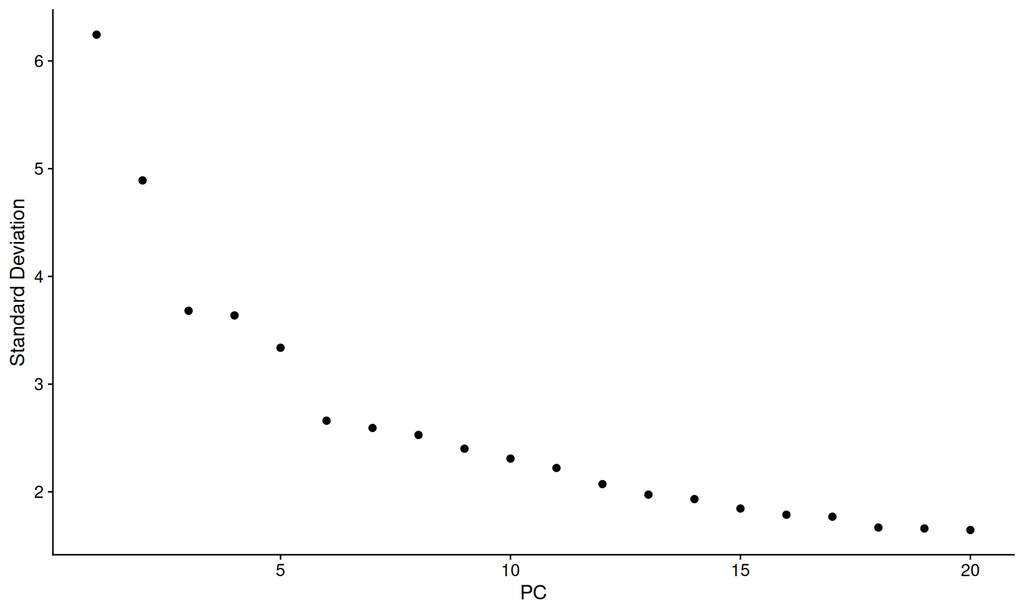

```r
ElbowPlot(Seurat_AD_WT)
```

Identifying the true dimensionality of a dataset – can be challenging/uncertain for the user. We therefore suggest these multiple approaches for users. The first is more supervised, exploring PCs to determine relevant sources of heterogeneity, and could be used in conjunction with GSEA for example. The second (`ElbowPlot`) The third is a heuristic that is commonly used, and can be calculated instantly. In this example, we might have been justified in choosing anything between PC 7-12 as a cutoff.

# Cluster the cells

Seurat applies a graph-based clustering approach, building upon initial strategies in (Macosko *et al*). Importantly, the *distance metric* which drives the clustering analysis (based on previously identified PCs) remains the same. However, our approach to partitioning the cellular distance matrix into clusters has dramatically improved. Our approach was heavily inspired by recent manuscripts which applied graph-based clustering approaches to scRNA-seq data [[SNN-Cliq, Xu and Su, Bioinformatics, 2015]](http://bioinformatics.oxfordjournals.org/content/early/2015/02/10/bioinformatics.btv088.abstract) and CyTOF data [[PhenoGraph, Levine *et al*., Cell, 2015]](http://www.ncbi.nlm.nih.gov/pubmed/26095251). Briefly, these methods embed cells in a graph structure - for example a K-nearest neighbor (KNN) graph, with edges drawn between cells with similar feature expression patterns, and then attempt to partition this graph into highly interconnected ‘quasi-cliques’ or ‘communities’.

To cluster the cells, we next apply modularity optimization techniques such as the Louvain algorithm (default) or SLM [[SLM, Blondel *et al*., Journal of Statistical Mechanics]](http://dx.doi.org/10.1088/1742-5468/2008/10/P10008), to iteratively group cells together, with the goal of optimizing the standard modularity function. The `FindClusters()` function implements this procedure, and contains a resolution parameter that sets the ‘granularity’ of the downstream clustering, with increased values leading to a greater number of clusters. We find that setting this parameter between 0.4-1.2 typically returns good results for single-cell datasets of around 3K cells. Optimal resolution often increases for larger datasets. The clusters can be found using the `Idents()` function.

```r
Seurat_AD_WT <- FindNeighbors(Seurat_AD_WT,reduction = "pca", dims = 1:13)
Seurat_AD_WT <- FindClusters(Seurat_AD_WT, resolution = 2) # the higher the number the higher the clusters
```

```
## Modularity Optimizer version 1.3.0 by Ludo Waltman and Nees Jan van Eck
##
## Number of nodes: 10809
## Number of edges: 371327
##
## Running Louvain algorithm...
## Maximum modularity in 10 random starts: 0.7867
## Number of communities: 25
## Elapsed time: 1 seconds
```

```r
# Look at cluster IDs of the first 5 cells
head(Idents(Seurat_AD_WT), 5)
```

```
## AD_AAACCTGAGATCTGCT-1 AD_AAACCTGAGCACAGGT-1 AD_AAACCTGAGGGCACTA-1
##                    14                    15                     2
## AD_AAACCTGCACATTCGA-1 AD_AAACCTGCAGGGTTAG-1
##                     5                    22
## Levels: 0 1 2 3 4 5 6 7 8 9 10 11 12 13 14 15 16 17 18 19 20 21 22 23 24
```

## Run non-linear dimensional reduction (UMAP/tSNE)

Seurat offers several non-linear dimensional reduction techniques, such as tSNE and UMAP, to visualize and explore these datasets. The goal of these algorithms is to learn underlying structure in the dataset, in order to place similar cells together in low-dimensional space. Therefore, cells that are grouped together within graph-based clusters determined above should co-localize on these dimension reduction plots.

While we and others have routinely found 2D visualization techniques like tSNE and UMAP to be valuable tools for exploring datasets, all visualization techniques have limitations, and cannot fully represent the complexity of the underlying data. In particular, these methods aim to preserve local distances in the dataset (i.e. ensuring that cells with very similar gene expression profiles co-localize), but often do not preserve more global relationships. We encourage users to leverage techniques like UMAP for visualization, but to avoid drawing biological conclusions solely on the basis of visualization techniques.

```r
Seurat_AD_WT <- RunUMAP(Seurat_AD_WT, dims = 1:13)
```

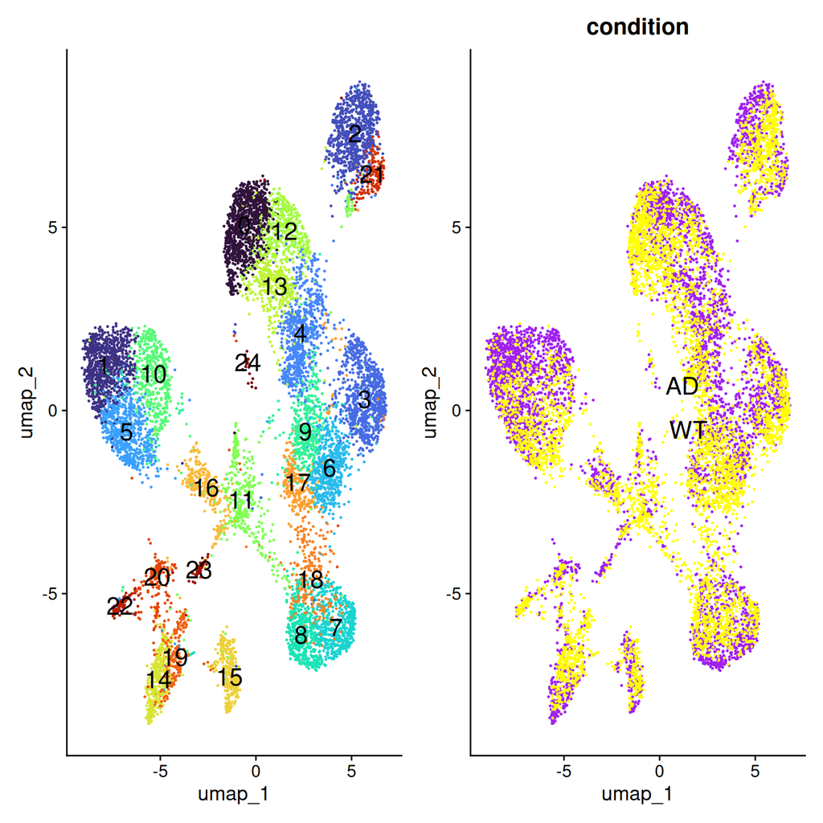

```r
N_clusters <-length(unique(Idents(Seurat_AD_WT)))
# note that you can set `label = TRUE` or use the LabelClusters function to help label individual clusters
plot1 <- DimPlot(Seurat_AD_WT, label = T, label.size = 6, reduction = 'umap', cols = turbo(N_clusters)) + NoLegend()
plot2 <- DimPlot(Seurat_AD_WT, label = T, label.size = 6, reduction = 'umap', group.by = 'condition', cols = c('purple', 'yellow'),  ) + NoLegend()
plot1 + plot2
```

## Integrate the datasets

Now we will re-run the analysis, but we will integrate the datasets beforehand!

The function IntegrateLayers() corrects technical batch effects across multiple separate data layers (samples/batches) to align shared cell types.

Seurat v5 enables streamlined integrative analysis using the IntegrateLayers function. The method currently supports five integration methods. Each of these methods performs integration in low-dimensional space, and returns a dimensional reduction (i.e. integrated.rpca) that aims to co-embed shared cell types across batches:

```r
Seurat_AD_WT <- IntegrateLayers(
  object = Seurat_AD_WT, method = CCAIntegration,
  orig.reduction = "pca", new.reduction = "integrated.cca",
  verbose = FALSE
)
```

## Clustering and UMAP on integrated data

```r
Seurat_AD_WT <- FindNeighbors(Seurat_AD_WT, reduction = "integrated.cca", dims = 1:13)
Seurat_AD_WT <- FindClusters(Seurat_AD_WT, resolution = 2, cluster.name = "cca_clusters")
```

```
## Modularity Optimizer version 1.3.0 by Ludo Waltman and Nees Jan van Eck
##
## Number of nodes: 10809
## Number of edges: 390057
##
## Running Louvain algorithm...
## Maximum modularity in 10 random starts: 0.8013
## Number of communities: 25
## Elapsed time: 1 seconds
```

```r
Seurat_AD_WT <- RunUMAP(Seurat_AD_WT, reduction = "integrated.cca", dims = 1:13, reduction.name = "umap.cca")
```

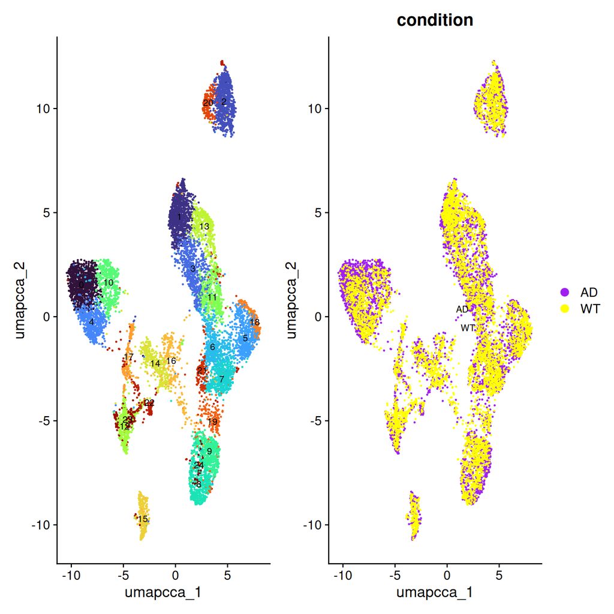

```r
N_clusters <-length(unique(Idents(Seurat_AD_WT)))
# note that you can set `label = TRUE` or use the LabelClusters function to help label individual clusters
plot3 <- DimPlot(Seurat_AD_WT, label = T, label.size = 3, reduction = 'umap.cca', cols = turbo(N_clusters)) + NoLegend()
plot4 <- DimPlot(Seurat_AD_WT, label = T, label.size = 3, reduction = 'umap.cca', group.by =  'condition', cols = c('purple', 'yellow') )
plot3 + plot4
```

## Compare non-integrated and integrated datasets

What does the CCA integration do?

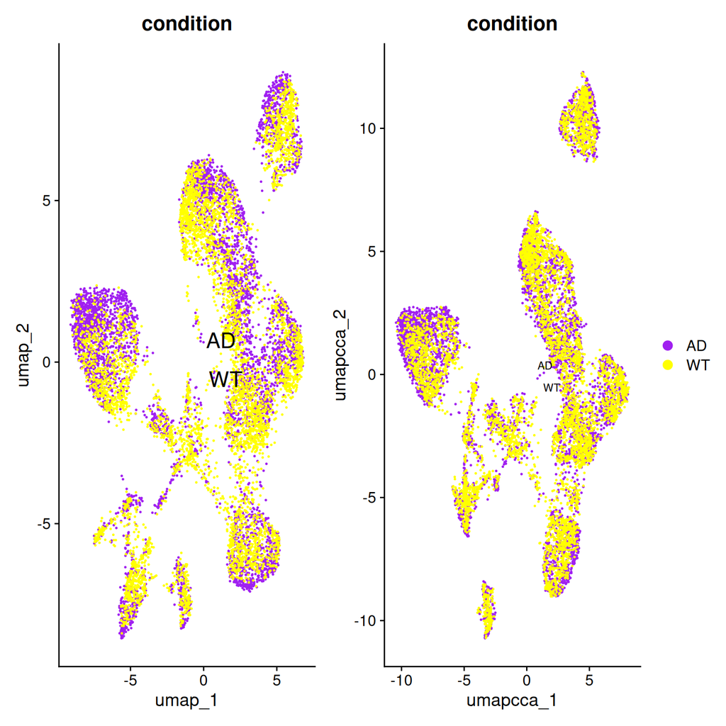

```r
# note that you can set `label = TRUE` or use the LabelClusters function to help label individual clusters
plot2 + plot4
```

## Re-join layers after integration

JoinLayers() simply combines separate sample layers back into a single unified layer without doing any mathematical batch correction. Concatenates individual sample matrices back into a single default counts or data, used after successful integration.

```r
Seurat_AD_WT[["RNA"]] <- JoinLayers(Seurat_AD_WT[["RNA"]])
```

## Look at Features

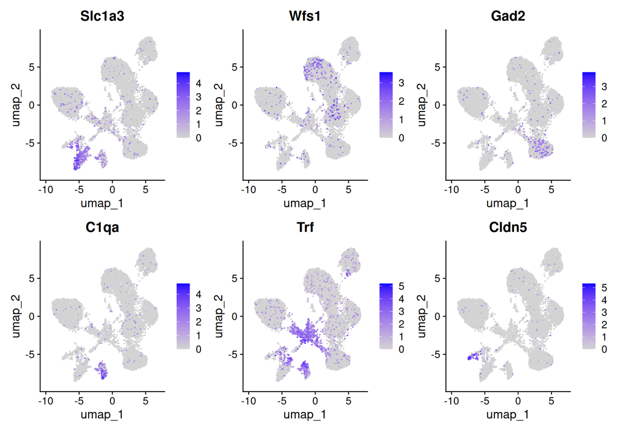

```r
FeaturePlot(
  object = Seurat_AD_WT,
  features = c(
    "Slc1a3", #Astrocytes
    "Wfs1", # Glut Neurons or Slc17a7
    "Gad2", # GABA neurons
    "C1qa", # Microglia
    "Trf", # Myelin-forming mature oligodendrocytes
    "Cldn5"), # Endothelial cells
  ncol = 3)
```

## Differential gene expression

Let’s llok at some genes across: - clusters - conditions (WT vs AD)

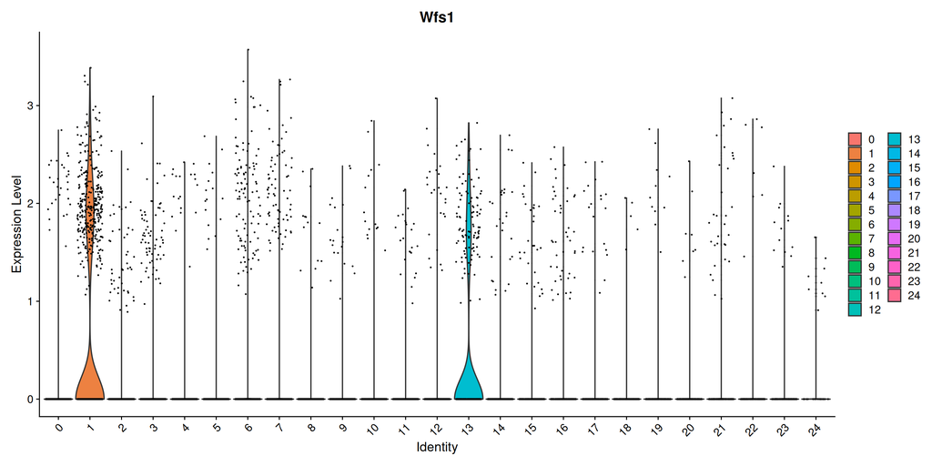

```r
VlnPlot(Seurat_AD_WT, 'Wfs1')
```

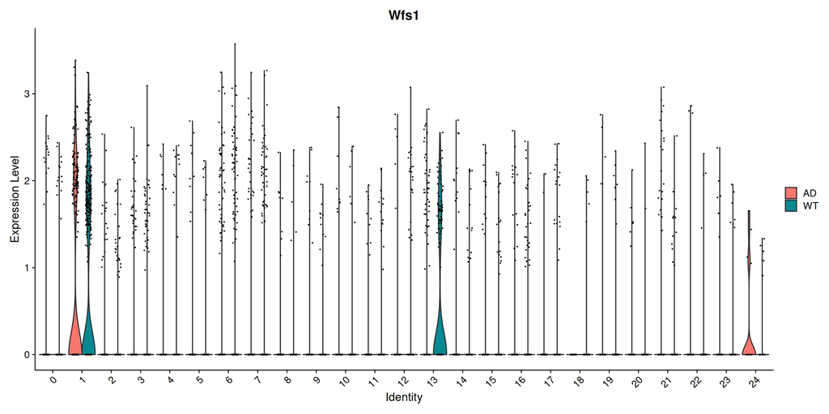

```r
VlnPlot(Seurat_AD_WT, 'Wfs1', split.by = 'condition')
```

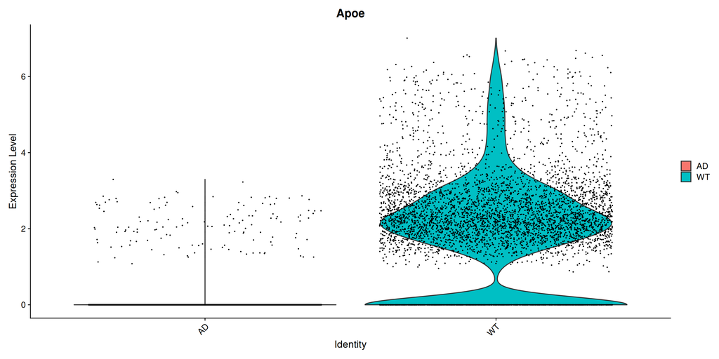

```r
VlnPlot(Seurat_AD_WT, 'Apoe', group.by = 'condition') # check knockout
```

This is to just prepare some marker genes Data taken from the publication

```r
# Cluster 0: Wfs1+,Dcn+,Rxfp1- CA1 pyramidal neurons (Excitatory neuron 1)
cluster0 <- c("Wfs1", "Dcn")

# Cluster 1: C1ql2+ Granule cell of the dentate gyrus (Excitatory neuron 2)
cluster1 <- c("C1ql2")

# Cluster 2: Wfs1+,Dcn-,Rxfp1+ CA1 pyramidal neurons (Excitatory neuron 3)
cluster2 <- c("Wfs1", "Rxfp1")

# Cluster 3: Bok+ CA3 pyramidal neurons (Excitatory neuron 4)
cluster3 <- c("Bok")

# Cluster 4: Wfs1-,Dcn-, pyramidal neurons (Excitatory neuron 5)
cluster4 <- c()  # no positive markers

# Cluster 5: Sst+,Erbb4+ CA1 basket cells (Inhibitory neuron 1)
cluster5 <- c("Sst", "Erbb4")

# Cluster 6: Slc1a3+ Astrocytes
cluster6 <- c("Slc1a3")

# Cluster 7: Trf+ Myelin-forming mature oligodendrocytes (MFOLs)
cluster7 <- c("Trf")

# Cluster 8: Vip+,Reln+,Htr3a+,Erbb4+ CA1 basket cells (Inhibitory neuron 2)
cluster8 <- c("Vip", "Reln", "Htr3a", "Erbb4")

# Cluster 9: Ndst4+,Rxfp1+,Dcn- CA1 pyramidal neurons (Excitatory neuron 6)
cluster9 <- c("Ndst4", "Rxfp1")

# Cluster 10: C1qa+,Trf+ Microglia
cluster10 <- c("C1qa", "Trf")

# Cluster 11: Cldn5+ Endothelial cells
cluster11 <- c("Cldn5")

# Cluster 12: Htr2c+,Glra1-  CA1 pyramidal cells (Excitatory neuron 7)
cluster12 <- c("Htr2c")

# Cluster 13: Htr2c+,Glra1+ CA1 pyramidal cells (Inhibitory neuron 3)
cluster13 <- c("Htr2c", "Glra1")

# Cluster 14: Amigo2+ CA2 pyramidal neurons (Excitatory neuron 8)
cluster14 <- c("Amigo2")

# Cluster 15: Pdgfra+ Oligodendrocyte precursor cells (OPCs)
cluster15 <- c("Pdgfra")

# Cluster 16: Reln+,Dcn+ CA1 pyramidal cells (Excitatory neuron 9)
cluster16 <- c("Reln", "Dcn")

# Combine all cluster vectors into one
all_genes <- c(
  cluster0, cluster1, cluster2, cluster3, cluster4, cluster5, cluster6,
  cluster7, cluster8, cluster9, cluster10, cluster11, cluster12, cluster13,
  cluster14, cluster15, cluster16
)

# Remove duplicates
all_genes <- unique(all_genes)
```

## Finding differentially expressed features (cluster biomarkers)

Seurat can help you find markers that define clusters via differential expression (DE). By default, it identifies positive and negative markers of a single cluster (specified in ident.1), compared to all other cells. FindAllMarkers() automates this process for all clusters, but you can also test groups of clusters vs. each other, or against all cells.

The results data frame has the following columns : p_val : p-value (unadjusted) avg_log2FC : log fold-change of the average expression between the two groups. Positive values indicate that the feature is more highly expressed in the first group. pct.1 : The percentage of cells where the feature is detected in the first group pct.2 : The percentage of cells where the feature is detected in the second group p_val_adj : Adjusted p-value, based on Bonferroni correction using all features in the dataset. If the ident.2 parameter is omitted or set to NULL, FindMarkers() will test for differentially expressed features between the group specified by ident.1 and all other cells. Additionally, the parameter only.pos can be set to TRUE to only search for positive markers, i.e. features that are more highly expressed in the ident.1 group.

FindConservedMarkers() helps to find conserved markers across conditions for a given cluster

In Seurat v5, we use the presto package (as described here and available for installation here), to dramatically improve the speed of DE analysis, particularly for large datasets. For users who are not using presto, you can examine the documentation for this function (?FindMarkers) to explore the min.pct and logfc.threshold parameters, which can be increased in order to increase the speed of DE testing.

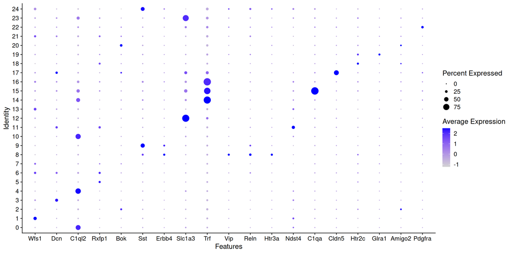

```r
DotPlot(Seurat_AD_WT, features= all_genes)
```

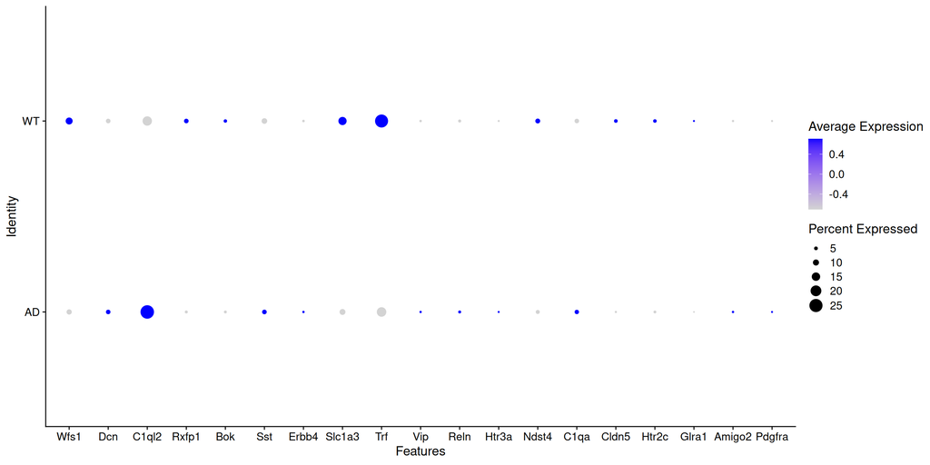

```r
DotPlot(Seurat_AD_WT, features= all_genes, group.by = "condition")
```

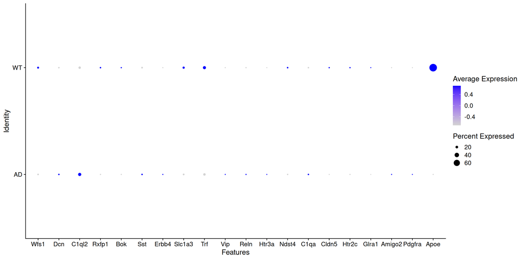

```r
DotPlot(Seurat_AD_WT, features= c(all_genes, 'Apoe'), group.by = "condition")
```

Compare the results of FindMarkers and FindConservedMarkers for a given cluster. Then contrast this with FindMarkers comparingWT and AD for a given cluser.

```r
# find all markers of cluster 5
Idents(Seurat_AD_WT) <- "seurat_clusters"
cluster13.markers <- FindMarkers(Seurat_AD_WT, ident.1 = "13", only.pos = TRUE)
head(cluster13.markers, n = 10)
```

|  | p_val | avg_log2FC | pct.1 | pct.2 | p_val_adj |
| --- | --- | --- | --- | --- | --- |
| Cpne7 | 0 | 1.6879099 | 0.937 | 0.438 | 0 |
| Pex5l | 0 | 1.3120834 | 0.820 | 0.415 | 0 |
| Chrd | 0 | 1.1649322 | 0.709 | 0.352 | 0 |
| Kcnn2 | 0 | 1.2946775 | 0.585 | 0.251 | 0 |
| Grin2b | 0 | 0.5478243 | 0.995 | 0.912 | 0 |
| Etv1 | 0 | 1.4413179 | 0.370 | 0.133 | 0 |
| Dcn | 0 | 1.6974387 | 0.230 | 0.061 | 0 |
| 3110035E14Rik | 0 | 1.0401466 | 0.577 | 0.280 | 0 |
| Ntm | 0 | 0.5916299 | 0.929 | 0.618 | 0 |
| Fibcd1 | 0 | 1.4950403 | 0.251 | 0.076 | 0 |

```r
Idents(Seurat_AD_WT) <- "seurat_clusters"
cluster13.conserved <- FindConservedMarkers(Seurat_AD_WT, ident.1 = "13", grouping.var = "condition", verbose = FALSE)

# Find markers across conditions
Seurat_AD_WT$cluster_cond <- paste(Seurat_AD_WT$seurat_clusters,
                                   Seurat_AD_WT$condition, sep = "_")

Idents(Seurat_AD_WT) <- "cluster_cond"
cluster13.markers.cond <- FindMarkers(Seurat_AD_WT, ident.1 = "13_WT", ident.2 = "13_AD")
```

### Plot the markers

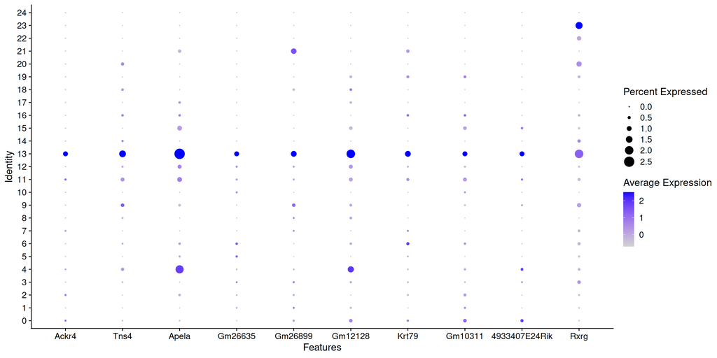

```r
cluster13.markers %>%
    dplyr::filter(avg_log2FC > 2 & p_val < 0.05) %>%
    slice_max(avg_log2FC, n = 10) -> top10

Idents(Seurat_AD_WT) <- "seurat_clusters"
DotPlot(Seurat_AD_WT, features = rownames(top10))
```

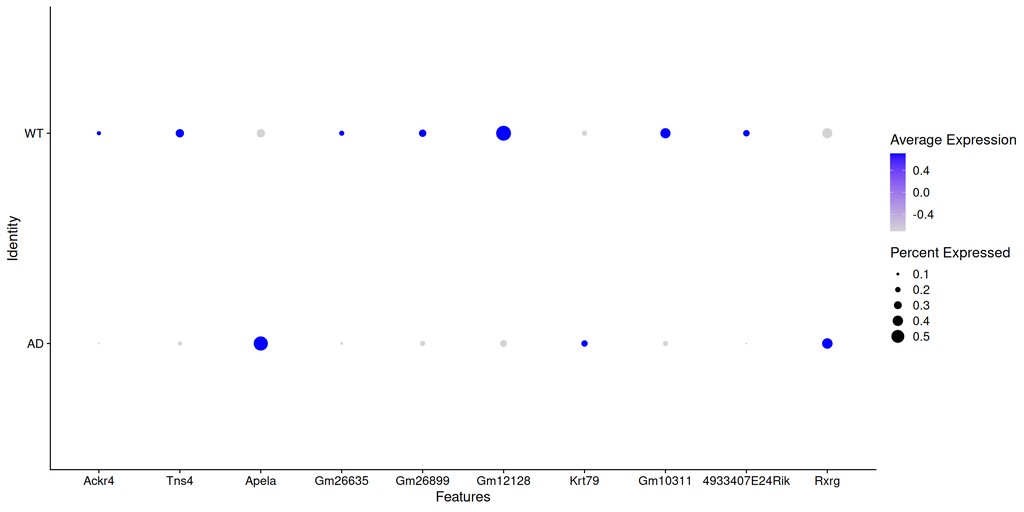

```r
DotPlot(Seurat_AD_WT, features = rownames(top10), group.by = "condition")
```

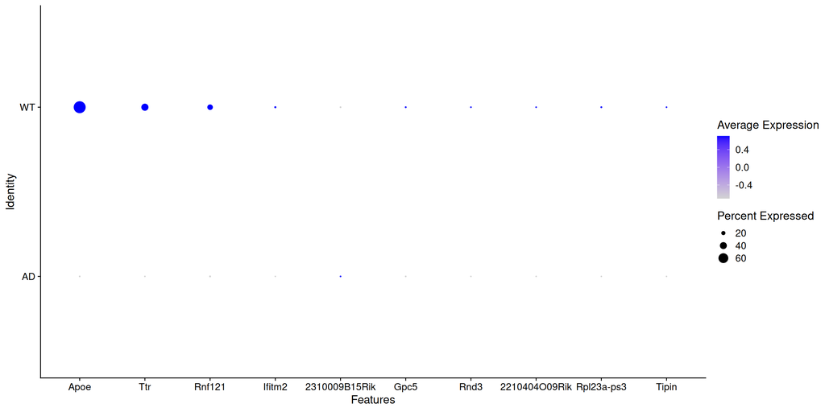

```r
cluster13.markers.cond %>%
    dplyr::filter(avg_log2FC > 2 & p_val < 0.05) %>%
    slice_max(avg_log2FC, n = 10) -> top10

Idents(Seurat_AD_WT) <- "seurat_clusters"
DotPlot(Seurat_AD_WT, features = rownames(top10), group.by = "condition")
```

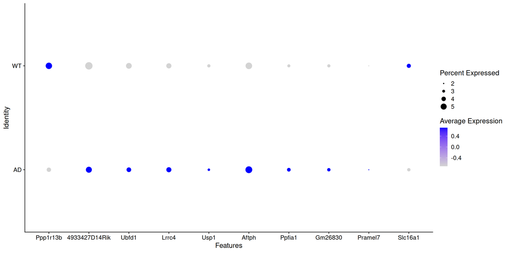

```r
cluster13.markers.cond %>%
    dplyr::filter(avg_log2FC > -2 & p_val < 0.05) %>%
    slice_min(avg_log2FC, n = 10) -> top10

Idents(Seurat_AD_WT) <- "seurat_clusters"
DotPlot(Seurat_AD_WT, features = rownames(top10), group.by = "condition")
```

# Azimuth

```r
Seurat_AD_WT <- RunAzimuth(Seurat_AD_WT, reference = "mousecortexref")
```

[output not shown]

```r
p1 <- DimPlot(Seurat_AD_WT, group.by = "predicted.celltype.l2", label = TRUE, label.size = 3) + NoLegend()
```

[output not shown]

```r
p2 <- DimPlot(Seurat_AD_WT, group.by = "Method")
```

[output not shown]

```r
p1 + p2
```

[output not shown]

# Export data to MapMyCells

We will export the count matrix and map the cells with Allen Brain atlas see: https://portal.brain-map.org/atlases-and-data/bkp/mapmycells use: https://knowledge.brain-map.org/mapmycells/process/ ## Extract the Count Matrix

```r
mat <- GetAssayData(object = subset(Seurat_AD_WT, downsample = 1000, subset = seurat_clusters %in% c(13)), assay = "RNA", slot = "counts")
```

[output not shown]

```r
# we need to transpose the matrix, as MapMyCells expects matrix in which rows are "cells" and columns are genes!
mat_t <- t(mat)
```

[output not shown]

```r
write.csv(mat_t, "./output/count_matrix_cluster13.csv")
```

[output not shown]